# Predicting depression using machine learning

This notebook looks into using various Python-based machine learning and data science libraries in an attempt to build a machine learning model capable of predicting whether or not someone has depression based on the following data

We're going to take the following aaproach:

1. Problem definition
2. Data
3. Evaluation
4. Features
5. Modelling
6. Experimentation

## 1. Problem Definition

In a statement,

> Given data about Students mental health, Can we predict whether or not they have depression

## 2. Data

This original data set was collected by a survey conducted by Google forms from University student in order to examine their current academic situation and mental health.

This is available on Kaggle. https://www.kaggle.com/datasets/shariful07/student-mental-health/data

## 3. Evaluation

> If we can reach 95% accuracy at predicting whether or not a student has depression during the proof of concept, we'll pursue the project.

## 4. Features

This is where you'll get different information about each of the features in your data.

# Data Dictionary

1. timestamp: Date and time of entry.
2. gender: gender of the student. (0 for female, 1 for male).
3. age: Age of the individual.
4. course: The academic course the individual is pursuing.
5. year: The academic course the individual is pursuing.
6. CGPA: Cumulative Grade Point Average of the individual's academic performance.
7. marital_status: The marital status of the individual (e.g., single, married)
8. depression: Presence or absence of symptoms related to depression.
9. anxiety: Presence or absence of symptoms related to anxiety.
10. panic_attack: Presence or absence of symptoms related to panic attacks.
11. specialist_treatment: Whether the individual is undergoing specialized treatment for any of the mental health conditions mentioned above.

## Preparing the tools

We'll going to use pandas. Matplotlib and Numpy for data analysis and manipulation

```python
## Import all the tools we need

## Regular EDA(exploratory data analysis) and plotting libraries
import numpy as np
import pandas as pd
import matplotlib.pyplot as plt
import seaborn as sns

# This line ensures plots appear inside the notebook
%matplotlib inline

# Models from Scikit-Learn
from sklearn.linear_model import LogisticRegression
from sklearn.neighbors import KNeighborsClassifier
from sklearn.ensemble import RandomForestClassifier

## Model evaluators
from sklearn.model_selection import train_test_split, cross_val_score
from sklearn.model_selection import RandomizedSearchCV, GridSearchCV
from sklearn.metrics import confusion_matrix, classification_report
from sklearn.metrics import precision_score, recall_score, f1_score

# from sklearn.metrics
from sklearn.metrics import RocCurveDisplay

import warnings

%config InlineBackend.rc = {'figure.figsize': (6, 6)}
warnings.filterwarnings("ignore")

from sklearn.metrics import accuracy_score
from sklearn.preprocessing import LabelEncoder
import plotly.express as px
```

## Load Data

```python
df = pd.read_csv("Student Mental health.csv") # 'DataFrame' shortened to 'df'
df.shape # (rows, columns)
```

```
(101, 11)
```

## Data Exploration (exploratory data analysis or EDA)

The goal here is to find out more about the data become a subject matter expert on the dataset you're working with.

1. What question(s) are you trying to solve (or prove wrong)?
2. What kind of data do you have and how do you treat different types?
3. What’s missing from the data and how do you deal with it?
4. Where are the outliers and why should you care about them?
5. How can you add, change or remove features to get more out of your data?

```python
df.info()
```

```
<class 'pandas.core.frame.DataFrame'>
RangeIndex: 101 entries, 0 to 100
Data columns (total 11 columns):
 #   Column                Non-Null Count  Dtype
---  ------                --------------  -----
 0   timestamp             101 non-null    object
 1   gender                101 non-null    object
 2   age                   100 non-null    float64
 3   course                101 non-null    object
 4   year                  101 non-null    object
 5   CGPA                  101 non-null    object
 6   marital_status        101 non-null    object
 7   depression            101 non-null    object
 8   anxiety               101 non-null    object
 9   panic_attack          101 non-null    object
 10  specialist_treatment  101 non-null    object
dtypes: float64(1), object(10)
memory usage: 8.8+ KB
```

```python
df.head()
```

|  | timestamp | gender | age | course | year | CGPA | marital_status | depression | anxiety | panic_attack | specialist_treatment |
| --- | --- | --- | --- | --- | --- | --- | --- | --- | --- | --- | --- |
| 0 | 8/7/2020 12:02 | Female | 18.0 | Engineering | year 1 | 3.00 - 3.49 | No | Yes | No | Yes | No |
| 1 | 8/7/2020 12:04 | Male | 21.0 | Islamic education | year 2 | 3.00 - 3.49 | No | No | Yes | No | No |
| 2 | 8/7/2020 12:05 | Male | 19.0 | BIT | Year 1 | 3.00 - 3.49 | No | Yes | Yes | Yes | No |
| 3 | 8/7/2020 12:06 | Female | 22.0 | Laws | year 3 | 3.00 - 3.49 | Yes | Yes | No | No | No |
| 4 | 8/7/2020 12:13 | Male | 23.0 | Mathemathics | year 4 | 3.00 - 3.49 | No | No | No | No | No |

```python
df.tail()
```

|  | timestamp | gender | age | course | year | CGPA | marital_status | depression | anxiety | panic_attack | specialist_treatment |
| --- | --- | --- | --- | --- | --- | --- | --- | --- | --- | --- | --- |
| 96 | 13/07/2020 19:56:49 | Female | 21.0 | BCS | year 1 | 3.50 - 4.00 | No | No | Yes | No | No |
| 97 | 13/07/2020 21:21:42 | Male | 18.0 | Engineering | Year 2 | 3.00 - 3.49 | No | Yes | Yes | No | No |
| 98 | 13/07/2020 21:22:56 | Female | 19.0 | Nursing | Year 3 | 3.50 - 4.00 | Yes | Yes | No | Yes | No |
| 99 | 13/07/2020 21:23:57 | Female | 23.0 | Pendidikan Islam | year 4 | 3.50 - 4.00 | No | No | No | No | No |
| 100 | 18/07/2020 20:16:21 | Male | 20.0 | Biomedical science | Year 2 | 3.00 - 3.49 | No | No | No | No | No |

```python
df.isnull().sum()
```

```
timestamp               0
gender                  0
age                     1
course                  0
year                    0
CGPA                    0
marital_status          0
depression              0
anxiety                 0
panic_attack            0
specialist_treatment    0
dtype: int64
```

```python
df.dropna(inplace=True)
```

```python
df.isnull().sum()
```

```
timestamp               0
gender                  0
age                     0
course                  0
year                    0
CGPA                    0
marital_status          0
depression              0
anxiety                 0
panic_attack            0
specialist_treatment    0
dtype: int64
```

```python
df.duplicated().sum()
```

```
0
```

```python
df.info()
```

```
<class 'pandas.core.frame.DataFrame'>
Index: 100 entries, 0 to 100
Data columns (total 11 columns):
 #   Column                Non-Null Count  Dtype
---  ------                --------------  -----
 0   timestamp             100 non-null    object
 1   gender                100 non-null    object
 2   age                   100 non-null    float64
 3   course                100 non-null    object
 4   year                  100 non-null    object
 5   CGPA                  100 non-null    object
 6   marital_status        100 non-null    object
 7   depression            100 non-null    object
 8   anxiety               100 non-null    object
 9   panic_attack          100 non-null    object
 10  specialist_treatment  100 non-null    object
dtypes: float64(1), object(10)
memory usage: 9.4+ KB
```

```python
# Let's find out how many of each class are there
df["depression"].value_counts()
```

```
depression
No     65
Yes    35
Name: count, dtype: int64
```

```python
new = df['year'].str.split(' ',n=1,expand=True)
df['X'] = new[0]
df['Y'] = new[1]
df["year"]=df['Y']
df=df.drop(columns=['X', 'Y'])
```

```python
df.year.unique()
```

```
array(['1', '2', '3', '4'], dtype=object)
```

```python
df.CGPA.unique()
```

```
array(['3.00 - 3.49', '3.50 - 4.00', '3.50 - 4.00 ', '2.50 - 2.99',
       '2.00 - 2.49', '0 - 1.99'], dtype=object)
```

```python
df["CGPA"]=df["CGPA"].str.strip(" ")
```

```python
df.CGPA.unique()
```

```
array(['3.00 - 3.49', '3.50 - 4.00', '2.50 - 2.99', '2.00 - 2.49',
       '0 - 1.99'], dtype=object)
```

```python
df['age'] = df['age'].astype(int)
```

```python
df.head()
```

|  | timestamp | gender | age | course | year | CGPA | marital_status | depression | anxiety | panic_attack | specialist_treatment |
| --- | --- | --- | --- | --- | --- | --- | --- | --- | --- | --- | --- |
| 0 | 8/7/2020 12:02 | Female | 18 | Engineering | 1 | 3.00 - 3.49 | No | Yes | No | Yes | No |
| 1 | 8/7/2020 12:04 | Male | 21 | Islamic education | 2 | 3.00 - 3.49 | No | No | Yes | No | No |
| 2 | 8/7/2020 12:05 | Male | 19 | BIT | 1 | 3.00 - 3.49 | No | Yes | Yes | Yes | No |
| 3 | 8/7/2020 12:06 | Female | 22 | Laws | 3 | 3.00 - 3.49 | Yes | Yes | No | No | No |
| 4 | 8/7/2020 12:13 | Male | 23 | Mathemathics | 4 | 3.00 - 3.49 | No | No | No | No | No |

```python
df.drop("timestamp",axis=1,inplace=True)
```

```python
df.info()
```

```
<class 'pandas.core.frame.DataFrame'>
Index: 100 entries, 0 to 100
Data columns (total 10 columns):
 #   Column                Non-Null Count  Dtype
---  ------                --------------  -----
 0   gender                100 non-null    object
 1   age                   100 non-null    int32
 2   course                100 non-null    object
 3   year                  100 non-null    object
 4   CGPA                  100 non-null    object
 5   marital_status        100 non-null    object
 6   depression            100 non-null    object
 7   anxiety               100 non-null    object
 8   panic_attack          100 non-null    object
 9   specialist_treatment  100 non-null    object
dtypes: int32(1), object(9)
memory usage: 8.2+ KB
```

```python
df['year'] = df['year'].astype(int)
df.info()
```

```
<class 'pandas.core.frame.DataFrame'>
Index: 100 entries, 0 to 100
Data columns (total 10 columns):
 #   Column                Non-Null Count  Dtype
---  ------                --------------  -----
 0   gender                100 non-null    object
 1   age                   100 non-null    int32
 2   course                100 non-null    object
 3   year                  100 non-null    int32
 4   CGPA                  100 non-null    object
 5   marital_status        100 non-null    object
 6   depression            100 non-null    object
 7   anxiety               100 non-null    object
 8   panic_attack          100 non-null    object
 9   specialist_treatment  100 non-null    object
dtypes: int32(2), object(8)
memory usage: 7.8+ KB
```

```python
df.age.unique()
```

```
array([18, 21, 19, 22, 23, 20, 24])
```

## Data Visualization

```python
df.gender.value_counts()
fig = px.histogram(df, x="gender", color="gender")
fig.show()
```

```python
fig = px.histogram(df, x="course", color="course")
fig.show()
```

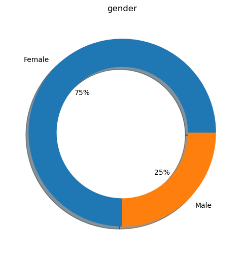

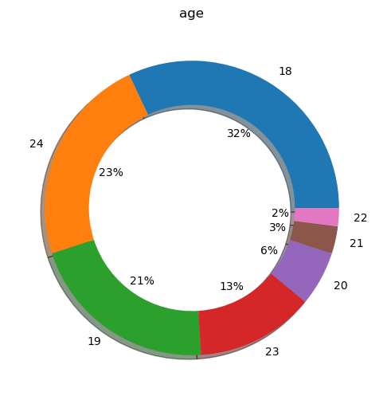

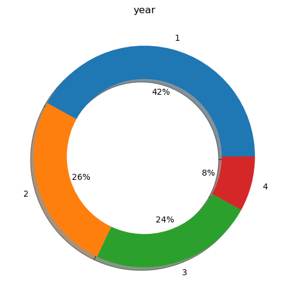

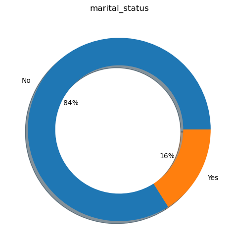

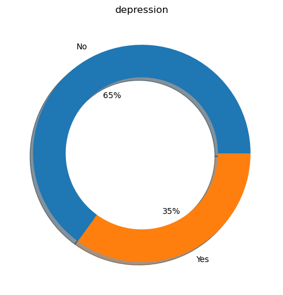

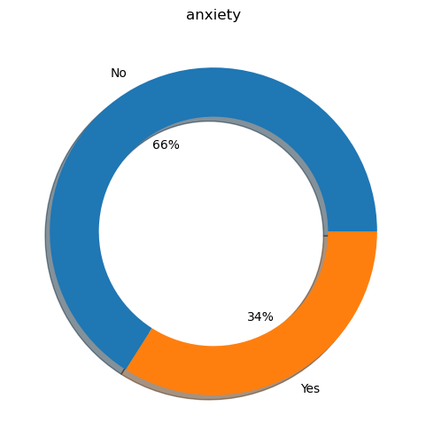

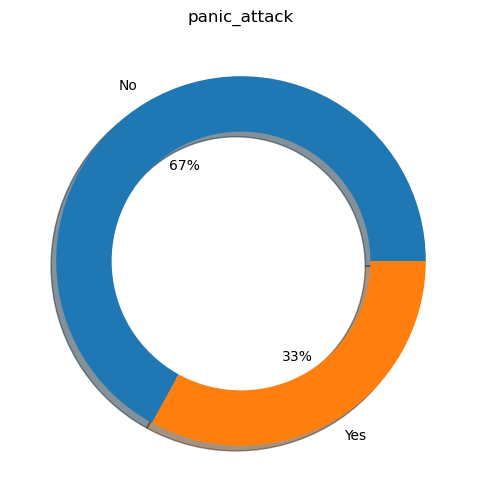

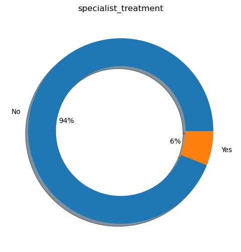

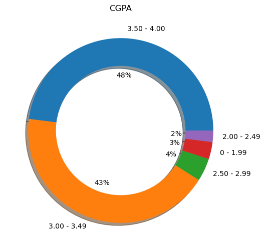

```python
for i in ['gender','age','year','marital_status','depression','anxiety','panic_attack','specialist_treatment', 'CGPA']:
    data = df[i].value_counts()
    plt.pie(data, labels=data.index,autopct='%.0f%%',shadow=True,wedgeprops={"width":0.3})
    plt.title(i)
    plt.show()
```

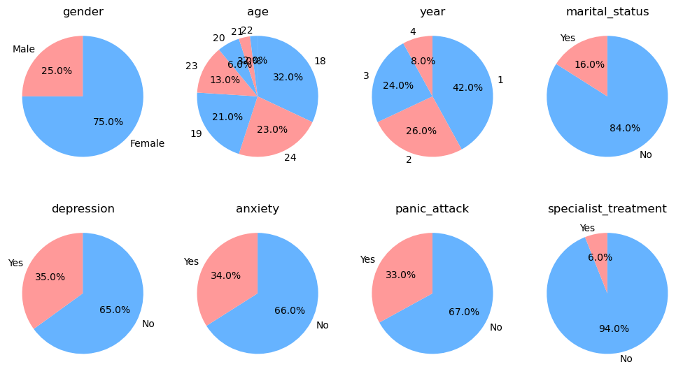

```python
columns_for_pie = ['gender', 'age', 'year', 'marital_status', 'depression', 'anxiety', 'panic_attack', 'specialist_treatment']

# Define the colors
colors = ['#66b3ff', '#ff9999']

num_rows = 2
num_cols = 4
fig, axes = plt.subplots(nrows=num_rows, ncols=num_cols, figsize=(10, 6))

axes = axes.flatten()

for i, column in enumerate(columns_for_pie):
    # Get value counts and percentages
    var_counts = df[column].value_counts()
    var_percentages = var_counts / df.shape[0]

    ax = axes[i]
    ax.pie(var_percentages, colors=colors, labels=var_percentages.index, startangle=90, counterclock=False, autopct='%1.1f%%')
    ax.set_title(column)

for j in range(len(columns_for_pie), len(axes)):
    axes[j].axis('off')

fig.tight_layout()

plt.show()
```

```python
fig = px.box(df, x="gender", y="age",color="gender", notched=True, # used notched shape
             title="Box plot of Gender",)
fig.show()
```

```python
fig = px.box(df, x="marital_status", y="age",color="marital_status", notched=True, # used notched shape
             title="Box plot of status")
fig.show()
```

## Since the age of marriage is 18 and over in the law, the average age of married people is 21

```python
fig = px.box(df, x="year", y="age",color="year", notched=True, # used notched shape
             title="Box plot of study",)
fig.show()
```

## While the average age of the 1st and 2nd year students is close to each other, the average age increases as the grade level increases.

```python
fig = px.histogram(df, x="depression",
             color='gender', barmode='group',
             height=400)
fig.show()
```

```python
fig = px.histogram(df, x="depression",
             color='CGPA', barmode='group',
             height=400)
fig.show()
```

```python
fig = px.histogram(df, x="depression",
             color='marital_status', barmode='group',
             height=400)
fig.show()
```

```python
fig = px.histogram(df, x="depression",
             color='course', barmode='group',
             height=400)
fig.show()
```

```python
df.info()
```

```
<class 'pandas.core.frame.DataFrame'>
Index: 100 entries, 0 to 100
Data columns (total 10 columns):
 #   Column                Non-Null Count  Dtype
---  ------                --------------  -----
 0   gender                100 non-null    object
 1   age                   100 non-null    int32
 2   course                100 non-null    object
 3   year                  100 non-null    int32
 4   CGPA                  100 non-null    object
 5   marital_status        100 non-null    object
 6   depression            100 non-null    object
 7   anxiety               100 non-null    object
 8   panic_attack          100 non-null    object
 9   specialist_treatment  100 non-null    object
dtypes: int32(2), object(8)
memory usage: 7.8+ KB
```

```python
df.replace("0 - 1.99", "0",inplace=True)
df.replace('2.00 - 2.49', "1",inplace=True)
df.replace('2.50 - 2.99', "2",inplace=True)
df.replace('3.50 - 4.00', "3",inplace=True)
df.replace('3.00 - 3.49', "4",inplace=True)
df['CGPA'] = df['CGPA'].astype('category')
```

```python
df['gender'] = df['gender'].apply(lambda x: 0 if x == 'Female' else 1)
df['gender'] = df['gender'].astype('category')
```

```python
for column in ['marital_status','depression','anxiety','panic_attack','specialist_treatment']:
    df[column] = df[column].apply(lambda x: 0 if x == 'No' else 1)
    df[column] = df[column].astype('category')
```

```python
pip install matplotlib-venn
```

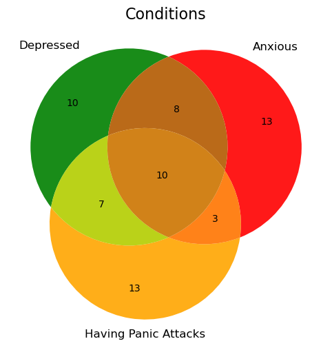

```python
from matplotlib_venn import venn3
depressed = df[(df["depression"] == 1)]
anxious = df[(df["anxiety"] == 1)]
panicking = df[(df["panic_attack"] == 1)]

venn3(subsets = [set(depressed.index),
                 set(anxious.index),
                 set(panicking.index)],
      set_labels = ("Depressed", "Anxious", "Having Panic Attacks"),
      set_colors = ("Green", "Red", "Orange"),
      alpha = 0.9)

plt.title("Conditions", fontsize = 16)
plt.show()
```

```python
df['year'] = df['year'].astype(str).str.extract('(\d+)').astype(int)
```

```python
from sklearn.preprocessing import LabelEncoder

le = LabelEncoder()
cat_cols = ['gender', 'marital_status', 'depression', 'anxiety', 'panic_attack', 'specialist_treatment']

for col in cat_cols:
    df[col] = le.fit_transform(df[col])

df
```

|  | gender | age | course | year | CGPA | marital_status | depression | anxiety | panic_attack | specialist_treatment |
| --- | --- | --- | --- | --- | --- | --- | --- | --- | --- | --- |
| 0 | 0 | 18 | Engineering | 1 | 4 | 0 | 1 | 0 | 1 | 0 |
| 1 | 1 | 21 | Islamic education | 2 | 4 | 0 | 0 | 1 | 0 | 0 |
| 2 | 1 | 19 | BIT | 1 | 4 | 0 | 1 | 1 | 1 | 0 |
| 3 | 0 | 22 | Laws | 3 | 4 | 1 | 1 | 0 | 0 | 0 |
| 4 | 1 | 23 | Mathemathics | 4 | 4 | 0 | 0 | 0 | 0 | 0 |
| ... | ... | ... | ... | ... | ... | ... | ... | ... | ... | ... |
| 96 | 0 | 21 | BCS | 1 | 3 | 0 | 0 | 1 | 0 | 0 |
| 97 | 1 | 18 | Engineering | 2 | 4 | 0 | 1 | 1 | 0 | 0 |
| 98 | 0 | 19 | Nursing | 3 | 3 | 1 | 1 | 0 | 1 | 0 |
| 99 | 0 | 23 | Pendidikan Islam | 4 | 3 | 0 | 0 | 0 | 0 | 0 |
| 100 | 1 | 20 | Biomedical science | 2 | 4 | 0 | 0 | 0 | 0 | 0 |

100 rows × 10 columns

```python
df.info()
```

```
<class 'pandas.core.frame.DataFrame'>
Index: 100 entries, 0 to 100
Data columns (total 10 columns):
 #   Column                Non-Null Count  Dtype
---  ------                --------------  -----
 0   gender                100 non-null    int64
 1   age                   100 non-null    int32
 2   course                100 non-null    object
 3   year                  100 non-null    int32
 4   CGPA                  100 non-null    category
 5   marital_status        100 non-null    int64
 6   depression            100 non-null    int64
 7   anxiety               100 non-null    int64
 8   panic_attack          100 non-null    int64
 9   specialist_treatment  100 non-null    int64
dtypes: category(1), int32(2), int64(6), object(1)
memory usage: 7.3+ KB
```

```python
def calculate_cgpa(x):
    if isinstance(x, str) and '-' in x:
        first, second = x.split('-')
        return (float(first.strip()) + float(second.strip())) / 2
    else:
        return x

df['CGPA'] = df['CGPA'].apply(calculate_cgpa)
```

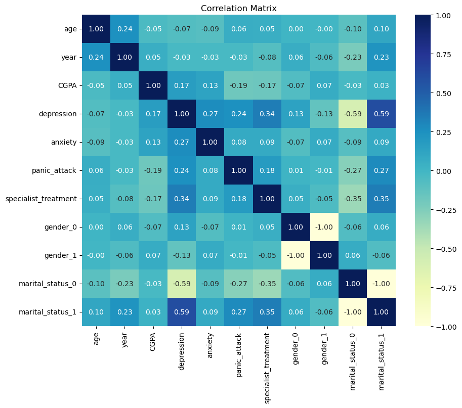

```python
# Select columns
selected_cols = ['gender', 'age', 'year', 'CGPA', 'marital_status', 'depression', 'anxiety', 'panic_attack', 'specialist_treatment']

# Subset the DataFrame with selected columns
selected_df = df[selected_cols]

# Remove 'course' from the selected columns list
selected_cols_no_course = [col for col in selected_cols if col != 'course']

# Remove 'course' column from DataFrame
selected_df_no_course = selected_df[selected_cols_no_course]

# One-hot encode categorical columns
encoded_df = pd.get_dummies(selected_df_no_course, columns=['gender', 'marital_status'])

# Calculate correlation matrix
corr_matrix = encoded_df.corr()

# Plot heatmap
plt.figure(figsize=(10, 8))
sns.heatmap(corr_matrix, annot=True, cmap='YlGnBu', fmt='.2f', annot_kws={'size': 10})
plt.title('Correlation Matrix')
plt.show()
```

```python
#Course Distrbution
stu_course = df['course'].value_counts().reset_index()
stu_course.columns = ['course', 'value_counts']
px.pie(stu_course,names='course',values='value_counts', width = 600, height = 800)
```

```python
#CGPA distibution
stu_cgpa = df['CGPA'].value_counts().reset_index()
stu_cgpa.columns = ['CGPA', 'value_counts']
px.pie(stu_cgpa,names='CGPA',values='value_counts', width = 600, height = 500)
```

```python
df.info()
```

```
<class 'pandas.core.frame.DataFrame'>
Index: 100 entries, 0 to 100
Data columns (total 10 columns):
 #   Column                Non-Null Count  Dtype
---  ------                --------------  -----
 0   gender                100 non-null    int64
 1   age                   100 non-null    int32
 2   course                100 non-null    object
 3   year                  100 non-null    int32
 4   CGPA                  100 non-null    category
 5   marital_status        100 non-null    int64
 6   depression            100 non-null    int64
 7   anxiety               100 non-null    int64
 8   panic_attack          100 non-null    int64
 9   specialist_treatment  100 non-null    int64
dtypes: category(1), int32(2), int64(6), object(1)
memory usage: 7.3+ KB
```

```python
df = pd.get_dummies(df, columns=['course'])
```

```python
df.shape
```

```
(100, 58)
```

```python
df.info()
```

```
<class 'pandas.core.frame.DataFrame'>
Index: 100 entries, 0 to 100
Data columns (total 58 columns):
 #   Column                          Non-Null Count  Dtype
---  ------                          --------------  -----
 0   gender                          100 non-null    int64
 1   age                             100 non-null    int32
 2   year                            100 non-null    int32
 3   CGPA                            100 non-null    category
 4   marital_status                  100 non-null    int64
 5   depression                      100 non-null    int64
 6   anxiety                         100 non-null    int64
 7   panic_attack                    100 non-null    int64
 8   specialist_treatment            100 non-null    int64
 9   course_ALA                      100 non-null    bool
```

[output cut: 50 more lines]

```python
for i in df.iloc[:,9:]:
    df[i]=df[i].astype(int).astype("category")
```

```python
df
```

|  | gender | age | year | CGPA | marital_status | depression | anxiety | panic_attack | specialist_treatment | course_ALA | ... | course_Pendidikan Islam | course_Pendidikan Islam | course_Pendidikan islam | course_Psychology | course_Radiography | course_TAASL | course_Usuluddin | course_engin | course_koe | course_psychology |
| --- | --- | --- | --- | --- | --- | --- | --- | --- | --- | --- | --- | --- | --- | --- | --- | --- | --- | --- | --- | --- | --- |
| 0 | 0 | 18 | 1 | 4 | 0 | 1 | 0 | 1 | 0 | 0 | ... | 0 | 0 | 0 | 0 | 0 | 0 | 0 | 0 | 0 | 0 |
| 1 | 1 | 21 | 2 | 4 | 0 | 0 | 1 | 0 | 0 | 0 | ... | 0 | 0 | 0 | 0 | 0 | 0 | 0 | 0 | 0 | 0 |
| 2 | 1 | 19 | 1 | 4 | 0 | 1 | 1 | 1 | 0 | 0 | ... | 0 | 0 | 0 | 0 | 0 | 0 | 0 | 0 | 0 | 0 |
| 3 | 0 | 22 | 3 | 4 | 1 | 1 | 0 | 0 | 0 | 0 | ... | 0 | 0 | 0 | 0 | 0 | 0 | 0 | 0 | 0 | 0 |
| 4 | 1 | 23 | 4 | 4 | 0 | 0 | 0 | 0 | 0 | 0 | ... | 0 | 0 | 0 | 0 | 0 | 0 | 0 | 0 | 0 | 0 |
| ... | ... | ... | ... | ... | ... | ... | ... | ... | ... | ... | ... | ... | ... | ... | ... | ... | ... | ... | ... | ... | ... |
| 96 | 0 | 21 | 1 | 3 | 0 | 0 | 1 | 0 | 0 | 0 | ... | 0 | 0 | 0 | 0 | 0 | 0 | 0 | 0 | 0 | 0 |
| 97 | 1 | 18 | 2 | 4 | 0 | 1 | 1 | 0 | 0 | 0 | ... | 0 | 0 | 0 | 0 | 0 | 0 | 0 | 0 | 0 | 0 |
| 98 | 0 | 19 | 3 | 3 | 1 | 1 | 0 | 1 | 0 | 0 | ... | 0 | 0 | 0 | 0 | 0 | 0 | 0 | 0 | 0 | 0 |
| 99 | 0 | 23 | 4 | 3 | 0 | 0 | 0 | 0 | 0 | 0 | ... | 1 | 0 | 0 | 0 | 0 | 0 | 0 | 0 | 0 | 0 |
| 100 | 1 | 20 | 2 | 4 | 0 | 0 | 0 | 0 | 0 | 0 | ... | 0 | 0 | 0 | 0 | 0 | 0 | 0 | 0 | 0 | 0 |

100 rows × 58 columns

```python
df.info()
```

```
<class 'pandas.core.frame.DataFrame'>
Index: 100 entries, 0 to 100
Data columns (total 58 columns):
 #   Column                          Non-Null Count  Dtype
---  ------                          --------------  -----
 0   gender                          100 non-null    int64
 1   age                             100 non-null    int32
 2   year                            100 non-null    int32
 3   CGPA                            100 non-null    category
 4   marital_status                  100 non-null    int64
 5   depression                      100 non-null    int64
 6   anxiety                         100 non-null    int64
 7   panic_attack                    100 non-null    int64
 8   specialist_treatment            100 non-null    int64
 9   course_ALA                      100 non-null    category
```

[output cut: 50 more lines]

## Data Modelling

```python
df.head()
```

|  | gender | age | year | CGPA | marital_status | depression | anxiety | panic_attack | specialist_treatment | course_ALA | ... | course_Pendidikan Islam | course_Pendidikan Islam | course_Pendidikan islam | course_Psychology | course_Radiography | course_TAASL | course_Usuluddin | course_engin | course_koe | course_psychology |
| --- | --- | --- | --- | --- | --- | --- | --- | --- | --- | --- | --- | --- | --- | --- | --- | --- | --- | --- | --- | --- | --- |
| 0 | 0 | 18 | 1 | 4 | 0 | 1 | 0 | 1 | 0 | 0 | ... | 0 | 0 | 0 | 0 | 0 | 0 | 0 | 0 | 0 | 0 |
| 1 | 1 | 21 | 2 | 4 | 0 | 0 | 1 | 0 | 0 | 0 | ... | 0 | 0 | 0 | 0 | 0 | 0 | 0 | 0 | 0 | 0 |
| 2 | 1 | 19 | 1 | 4 | 0 | 1 | 1 | 1 | 0 | 0 | ... | 0 | 0 | 0 | 0 | 0 | 0 | 0 | 0 | 0 | 0 |
| 3 | 0 | 22 | 3 | 4 | 1 | 1 | 0 | 0 | 0 | 0 | ... | 0 | 0 | 0 | 0 | 0 | 0 | 0 | 0 | 0 | 0 |
| 4 | 1 | 23 | 4 | 4 | 0 | 0 | 0 | 0 | 0 | 0 | ... | 0 | 0 | 0 | 0 | 0 | 0 | 0 | 0 | 0 | 0 |

5 rows × 58 columns

```python
from sklearn.model_selection import train_test_split
X = df.drop(["depression"],axis=1)
y= df["depression"]
X_train, X_test, y_train, y_test = train_test_split(X, y,test_size=0.2,random_state =15)
```

```python
X
```

|  | gender | age | year | CGPA | marital_status | anxiety | panic_attack | specialist_treatment | course_ALA | course_Accounting | ... | course_Pendidikan Islam | course_Pendidikan Islam | course_Pendidikan islam | course_Psychology | course_Radiography | course_TAASL | course_Usuluddin | course_engin | course_koe | course_psychology |
| --- | --- | --- | --- | --- | --- | --- | --- | --- | --- | --- | --- | --- | --- | --- | --- | --- | --- | --- | --- | --- | --- |
| 0 | 0 | 18 | 1 | 4 | 0 | 0 | 1 | 0 | 0 | 0 | ... | 0 | 0 | 0 | 0 | 0 | 0 | 0 | 0 | 0 | 0 |
| 1 | 1 | 21 | 2 | 4 | 0 | 1 | 0 | 0 | 0 | 0 | ... | 0 | 0 | 0 | 0 | 0 | 0 | 0 | 0 | 0 | 0 |
| 2 | 1 | 19 | 1 | 4 | 0 | 1 | 1 | 0 | 0 | 0 | ... | 0 | 0 | 0 | 0 | 0 | 0 | 0 | 0 | 0 | 0 |
| 3 | 0 | 22 | 3 | 4 | 1 | 0 | 0 | 0 | 0 | 0 | ... | 0 | 0 | 0 | 0 | 0 | 0 | 0 | 0 | 0 | 0 |
| 4 | 1 | 23 | 4 | 4 | 0 | 0 | 0 | 0 | 0 | 0 | ... | 0 | 0 | 0 | 0 | 0 | 0 | 0 | 0 | 0 | 0 |
| ... | ... | ... | ... | ... | ... | ... | ... | ... | ... | ... | ... | ... | ... | ... | ... | ... | ... | ... | ... | ... | ... |
| 96 | 0 | 21 | 1 | 3 | 0 | 1 | 0 | 0 | 0 | 0 | ... | 0 | 0 | 0 | 0 | 0 | 0 | 0 | 0 | 0 | 0 |
| 97 | 1 | 18 | 2 | 4 | 0 | 1 | 0 | 0 | 0 | 0 | ... | 0 | 0 | 0 | 0 | 0 | 0 | 0 | 0 | 0 | 0 |
| 98 | 0 | 19 | 3 | 3 | 1 | 0 | 1 | 0 | 0 | 0 | ... | 0 | 0 | 0 | 0 | 0 | 0 | 0 | 0 | 0 | 0 |
| 99 | 0 | 23 | 4 | 3 | 0 | 0 | 0 | 0 | 0 | 0 | ... | 1 | 0 | 0 | 0 | 0 | 0 | 0 | 0 | 0 | 0 |
| 100 | 1 | 20 | 2 | 4 | 0 | 0 | 0 | 0 | 0 | 0 | ... | 0 | 0 | 0 | 0 | 0 | 0 | 0 | 0 | 0 | 0 |

100 rows × 57 columns

```python
y
```

```
0      1
1      0
2      1
3      1
4      0
      ..
96     0
97     1
98     1
99     0
100    0
Name: depression, Length: 100, dtype: int64
```

```python
X_train
```

|  | gender | age | year | CGPA | marital_status | anxiety | panic_attack | specialist_treatment | course_ALA | course_Accounting | ... | course_Pendidikan Islam | course_Pendidikan Islam | course_Pendidikan islam | course_Psychology | course_Radiography | course_TAASL | course_Usuluddin | course_engin | course_koe | course_psychology |
| --- | --- | --- | --- | --- | --- | --- | --- | --- | --- | --- | --- | --- | --- | --- | --- | --- | --- | --- | --- | --- | --- |
| 100 | 1 | 20 | 2 | 4 | 0 | 0 | 0 | 0 | 0 | 0 | ... | 0 | 0 | 0 | 0 | 0 | 0 | 0 | 0 | 0 | 0 |
| 3 | 0 | 22 | 3 | 4 | 1 | 0 | 0 | 0 | 0 | 0 | ... | 0 | 0 | 0 | 0 | 0 | 0 | 0 | 0 | 0 | 0 |
| 20 | 0 | 19 | 1 | 4 | 0 | 0 | 1 | 0 | 0 | 0 | ... | 0 | 0 | 0 | 0 | 0 | 0 | 0 | 0 | 0 | 0 |
| 56 | 1 | 23 | 3 | 3 | 0 | 0 | 0 | 0 | 0 | 0 | ... | 0 | 0 | 0 | 0 | 0 | 0 | 0 | 0 | 0 | 0 |
| 6 | 0 | 23 | 2 | 3 | 1 | 0 | 1 | 0 | 0 | 0 | ... | 0 | 0 | 1 | 0 | 0 | 0 | 0 | 0 | 0 | 0 |
| ... | ... | ... | ... | ... | ... | ... | ... | ... | ... | ... | ... | ... | ... | ... | ... | ... | ... | ... | ... | ... | ... |
| 28 | 0 | 24 | 3 | 3 | 1 | 1 | 1 | 1 | 0 | 0 | ... | 0 | 0 | 0 | 0 | 0 | 0 | 0 | 0 | 0 | 0 |
| 0 | 0 | 18 | 1 | 4 | 0 | 0 | 1 | 0 | 0 | 0 | ... | 0 | 0 | 0 | 0 | 0 | 0 | 0 | 0 | 0 | 0 |
| 5 | 1 | 19 | 2 | 3 | 0 | 0 | 1 | 0 | 0 | 0 | ... | 0 | 0 | 0 | 0 | 0 | 0 | 0 | 0 | 0 | 0 |
| 12 | 0 | 18 | 1 | 4 | 0 | 0 | 0 | 0 | 0 | 0 | ... | 0 | 0 | 0 | 0 | 0 | 0 | 0 | 0 | 0 | 0 |
| 73 | 1 | 18 | 1 | 0 | 0 | 0 | 0 | 0 | 0 | 0 | ... | 0 | 0 | 0 | 0 | 0 | 0 | 0 | 0 | 0 | 0 |

80 rows × 57 columns

```python
y_train, len(y_train)
```

```
(100    0
 3      1
 20     0
 56     0
 6      1
       ..
 28     1
 0      1
 5      0
 12     1
 73     0
 Name: depression, Length: 80, dtype: int64,
 80)
```

Now we've got our data split into training and test sets, it's time to build a machine learning model.

We'll train it (find the patterns) on the training set.

And we'll test it (use the patterns) on the test set.

We're going to try 2 differnt machine learning models:

1. Random Forest Classifier
2. K-Nearest Neighbours Classifier

```python
# Convert categorical columns to numerical using LabelEncoder
label_encoders = {column: LabelEncoder() for column in df.columns[df.dtypes == 'object']}
df[df.columns[df.dtypes == 'object']] = df[df.columns[df.dtypes == 'object']].apply(lambda col: label_encoders[col.name].fit_transform(col))

# RandomForestClassifier
RF = RandomForestClassifier(max_depth=13, max_features='log2', min_samples_leaf=1, min_samples_split=5, n_estimators=500)
RF.fit(X_train, y_train)
ypred = RF.predict(X_test)
accuracy_RF = accuracy_score(y_test, ypred)
print(f"RandomForest Accuracy: {accuracy_RF}")

# KNeighborsClassifier
knn_classifier = KNeighborsClassifier(n_neighbors=5)
knn_classifier.fit(X_train, y_train)
knn_predictions = knn_classifier.predict(X_test)
accuracy_knn = accuracy_score(y_test, knn_predictions)
print(f"KNN Accuracy: {accuracy_knn}")
```

```
RandomForest Accuracy: 0.95
KNN Accuracy: 0.6
```

### Model Comparison

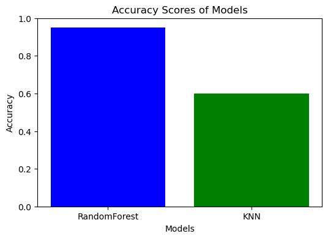

```python
accuracy_scores = [accuracy_RF, accuracy_knn]
models = ['RandomForest', 'KNN']

# Plotting the bar graph
plt.figure(figsize=(6, 4))
plt.bar(models, accuracy_scores, color=['blue', 'green'])
plt.title('Accuracy Scores of Models')
plt.xlabel('Models')
plt.ylabel('Accuracy')
plt.ylim(0.0, 1.0)
plt.show()
```

```python
def predict_price(gender,age,year,CGPA,marital_status,anxiety,panic_attack,specialist_treatment,course):
    loc_index1 = np.where(X.columns == "course_"+course)[0][0]

    x = np.zeros(len(X.columns))
    x[0] = gender
    x[1] = age
    x[2] = year
    x[3] = CGPA
    x[4] = marital_status
    x[5] = anxiety
    x[6] = panic_attack
    x[7] = specialist_treatment

    if loc_index1 >= 0:
        x[loc_index1] = 1

    return RF.predict([x])[0]
```

```python
reslt=predict_price(0,18,1,4,0,0,1,0,"Radiography")
```

```python
if reslt==0:
    print("Depression")
else:
    print("No Depression")
```

[output not shown]

```python
from sklearn.ensemble import AdaBoostClassifier
# Generate predictions with the best method
clf = AdaBoostClassifier()
clf.fit(X, y)
dfTestPredictions = clf.predict(X_test)

results = pd.DataFrame({'Index': X_test.index, 'depression': dfTestPredictions})
print(results)
# Save to file
results.to_csv('results.csv', index=False)
results.head()
```

```
    Index  depression
0      85           1
1      36           1
2      58           0
3      52           0
4      47           0
5      79           0
6      94           0
7      14           0
8      11           1
9      60           0
10     62           0
11     38           0
12     21           0
13     91           0
14      8           0
15     25           0
16     64           0
17      9           0
18     95           0
19     98           1
```

|  | Index | depression |
| --- | --- | --- |
| 0 | 85 | 1 |
| 1 | 36 | 1 |
| 2 | 58 | 0 |
| 3 | 52 | 0 |
| 4 | 47 | 0 |

## Saving the trained model

```python
import pickle
```

```python
filename = 'trained_model.pkl'
pickle.dump(RF, open(filename, 'wb'))
```

```python
# loading the saved model
loaded_model = pickle.load(open(filename, 'rb'))
```

```python
def predict_price(gender, age, year, CGPA, marital_status, anxiety, panic_attack, specialist_treatment, course):
    loc_index1 = np.where(X.columns == "course_" + course)[0][0]

    x = np.zeros(len(X.columns))
    x[0] = gender
    x[1] = age
    x[2] = year
    x[3] = CGPA

    x[4] = marital_status
    x[5] = anxiety
    x[6] = panic_attack
    x[7] = specialist_treatment

    if loc_index1 >= 0:
        x[loc_index1] = 1

    return loaded_model.predict([x])[0]
```

```python
reslt=predict_price(0,18,1,4,0,0,1,0,"Radiography")
```

```python
if reslt==0:
    print("Depression")
else:
    print("No Depression")
```

[output not shown]

```python
import pickle

# Assuming 'RF' is your trained model
filename = 'trained_model.pkl'

# Save the model in binary mode ('wb')
with open(filename, 'wb') as file:
    pickle.dump(RF, file)
```

```python
pip install scikit-learn
```